# Road Accidents Incidence

李冠緻、王聖曜

網址：https://www.kaggle.com/akshay4/road-accidents-incidence

### 0.0.1 目的與説明

本次欲探討題目為「在何種情況下，最有可能發生嚴重交通事故」，原始資料中事故嚴重程度分為三級，本處將歸類第一、二級為嚴重第三級為不嚴重；並且踢除一些沒有用的變數如事故發生的ID，車牌號碼等代碼性質之變數，另外因原始資料中存有年齡層與年齡兩變數，所以將保留年齡變數且剔除年齡層變數。

## 0.1 資料變數說明

Police Force：警力來源

Accident Severity：事故嚴重程度

Number of Vehicles：車輛數量

Number of Casualties：傷亡人數

Day of Week：星期

Time (HH:MM)：時間

Local Authority (District)：地區

1st Road Class：第一條道路類別

Road Type：道路型態

Speed limit：限速

Junction Detail：道路細節

Junction Control：交通管制

2nd Road Class：第二條道路類別

Pedestrian Crossing-Human Control：人行道控制

Pedestrian Crossing-Physical Facilities：人行道設施

Light Conditions：光線

Weather Conditions：天氣

Road Surface Conditions：路面狀況

Special Conditions at Site：號誌缺陷

Carriageway Hazards：車道危險

Urban or Rural Area：城市或農村地區

Did Police Officer Attend Scene of Accident：警察是否在事故現場

Vehicle Type：車輛類型

Towing and Articulation：拖吊車類型

Vehicle Manoeuvre：事故原因

Vehicle Location-Restricted Lane：車輛位置限制車道

Junction Location：交界處類型

Skidding and Overturning：打滑或翻車

Hit Object in Carriageway：在車道中撞擊物體

Vehicle Leaving Carriageway：車輛離開行車道類型

Hit Object off Carriageway：撞到物件

1st Point of Impact：第一個撞擊點

Was Vehicle Left Hand Drive：左駕

Journey Purpose of Driver：開車目的

Sex of Driver：駕駛性別

age Band of Driver:駕駛年齡層

Vehicle Propulsion Code：車輛動力來源類型

Age of Vehicle (manufacture)：車齡

Casualty Class:傷者類型

Sex of Casualty：傷者性別

Age Band of Casualty：傷者年齡層

Casualty Severity：受傷程度

Pedestrian Location：行人位置

Pedestrian Movement：行人動作

Car Passenger：車上乘客位置

Bus or Coach Passenger：公車上乘客動作

Pedestrian Road Maintenance Worker (From 2011)：是否有道路保養

Casualty Type：傷亡類型

Casualty IMD Decile：受害者貧困指數

Casualty Home Area Type：受害區域

# 1 EDA

## 1.1 觀察各變數資料的缺失狀況百分

|  | index | nacount |
| --- | --- | --- |
| 22 | vehicle_imd_decile | 1.0000000 |
| 20 | driver_imd_decile | 1.0000000 |
| 69 | casualty_imd_decile | 0.4766745 |
| 68 | casualty_home_area_type | 0.4220046 |
| 44 | 2nd_road_class | 0.3995500 |
| 43 | junction_control | 0.3955652 |
| 59 | age_of_casualty | 0.3583557 |
| 60 | age_band_of_casualty | 0.3583557 |
| 64 | car_passenger | 0.3491909 |
| 66 | pedestrian_road_maintenance_worker | 0.3484094 |
| 58 | sex_of_casualty | 0.3480870 |
| 65 | bus_or_coach_passenger | 0.3479608 |
| 63 | pedestrian_movement | 0.3478802 |
| 62 | pedestrian_location | 0.3478802 |
| 56 | casualty_reference | 0.3478732 |
| 57 | casualty_class | 0.3478732 |
| 67 | casualty_type | 0.3478732 |
| 61 | casualty_severity | 0.3478732 |
| 19 | age_of_vehicle | 0.3077198 |
| 17 | engine_capacity_(cc) | 0.2708013 |
| 18 | propulsion_code | 0.2688246 |
| 21 | driver_home_area_type | 0.1734302 |
| 15 | age_of_driver | 0.1061154 |
| 16 | age_band_of_driver | 0.1061154 |
| 55 | lsoa_of_accident_location | 0.0598568 |
| 45 | 2nd_road_number | 0.0052290 |
| 12 | was_vehicle_left_hand_drive? | 0.0039568 |
| 50 | road_surface_conditions | 0.0019101 |
| 46 | pedestrian_crossing-human_control | 0.0009848 |
| 3 | towing_and_articulation | 0.0009638 |
| 47 | pedestrian_crossing-physical_facilities | 0.0009182 |
| 51 | special_conditions_at_site | 0.0007605 |
| 52 | carriageway_hazards | 0.0006764 |
| 11 | 1st_point_of_impact | 0.0006203 |
| 4 | vehicle_manoeuvre | 0.0005537 |
| 5 | vehicle_location-restricted_lane | 0.0005362 |
| 7 | skidding_and_overturning | 0.0005327 |
| 8 | hit_object_in_carriageway | 0.0004872 |
| 9 | vehicle_leaving_carriageway | 0.0004801 |
| 6 | junction_location | 0.0002523 |
| 28 | latitude | 0.0002138 |
| 26 | location_northing_osgr | 0.0002138 |
| 25 | location_easting_osgr | 0.0002138 |
| 27 | longitude | 0.0002138 |
| 2 | vehicle_type | 0.0002033 |
| 35 | time | 0.0001157 |
| 13 | journey_purpose_of_driver | 0.0000876 |
| 14 | sex_of_driver | 0.0000701 |
| 54 | did_police_officer_attend_scene_of_accident | 0.0000701 |
| 42 | junction_detail | 0.0000070 |
| 10 | hit_object_off_carriageway | 0.0000070 |
| 33 | date | 0.0000000 |
| 23 | NUmber_of_Casualities_unique_to_accident_index | 0.0000000 |
| 24 | No_of_Vehicles_involved_unique_to_accident_index | 0.0000000 |
| 29 | police_force | 0.0000000 |
| 30 | accident_severity | 0.0000000 |
| 31 | number_of_vehicles | 0.0000000 |
| 32 | number_of_casualties | 0.0000000 |
| 34 | day_of_week | 0.0000000 |
| 41 | speed_limit | 0.0000000 |
| 1 | vehicle_reference | 0.0000000 |
| 36 | local_authority_(district) | 0.0000000 |
| 37 | local_authority_(highway) | 0.0000000 |
| 53 | urban_or_rural_area | 0.0000000 |
| 38 | 1st_road_class | 0.0000000 |
| 39 | 1st_road_number | 0.0000000 |
| 40 | road_type | 0.0000000 |
| 49 | weather_conditions | 0.0000000 |
| 48 | light_conditions | 0.0000000 |
| 0 | accident_index | 0.0000000 |

- 其中vehicle_imd_decile,driver_imd_decile兩行遺失值為百分百所以值接刪除兩變數，其他遺失部分則選擇刪去列。

## 1.2 時間序列

[figure not shown]

- 在這張圖可以知道，上班時間七點以及下班時間下午四點，為車禍發生的巔峰時刻。

## 1.3 變數觀察

```
##                 Var1                                             Var2
## 1  accident_severity                                     vehicle_type
## 2  accident_severity                          towing_and_articulation
## 3  accident_severity                                vehicle_manoeuvre
## 4  accident_severity                 vehicle_location-restricted_lane
## 5  accident_severity                                junction_location
## 6  accident_severity                         skidding_and_overturning
## 7  accident_severity                        hit_object_in_carriageway
## 8  accident_severity                      vehicle_leaving_carriageway
## 9  accident_severity                       hit_object_off_carriageway
## 10 accident_severity                              1st_point_of_impact
## 11 accident_severity                     was_vehicle_left_hand_drive?
## 12 accident_severity                        journey_purpose_of_driver
## 13 accident_severity                                    sex_of_driver
## 14 accident_severity                                    age_of_driver
```

[output cut: 95 more lines]

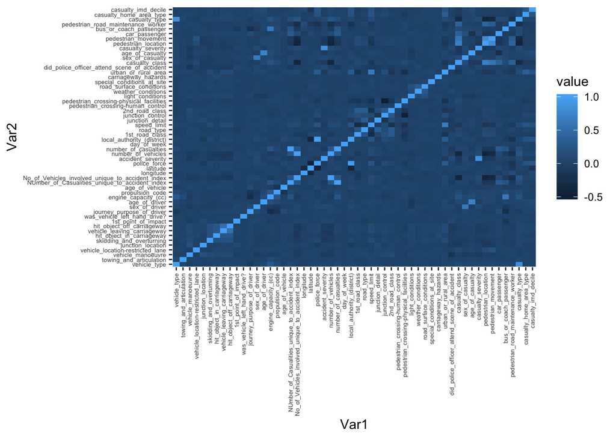

- 事故嚴重程度(accident_severity)跟受傷程度(casualty_severity)呈現高度線性相關，原因為casualty_severity為衡量受害者受傷程度指標，受害者受傷越嚴重死亡重傷車禍自然也越嚴重。

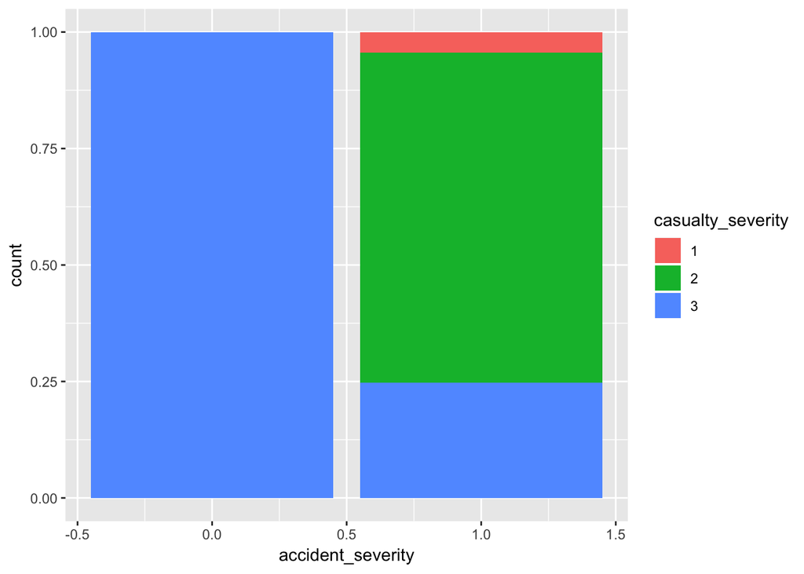

- 非嚴重車禍中受害者皆為輕傷，而嚴重車禍中有很大一部分的受害者為重傷少部分為死亡與輕傷。

## 1.4 最常撞重傷的車子

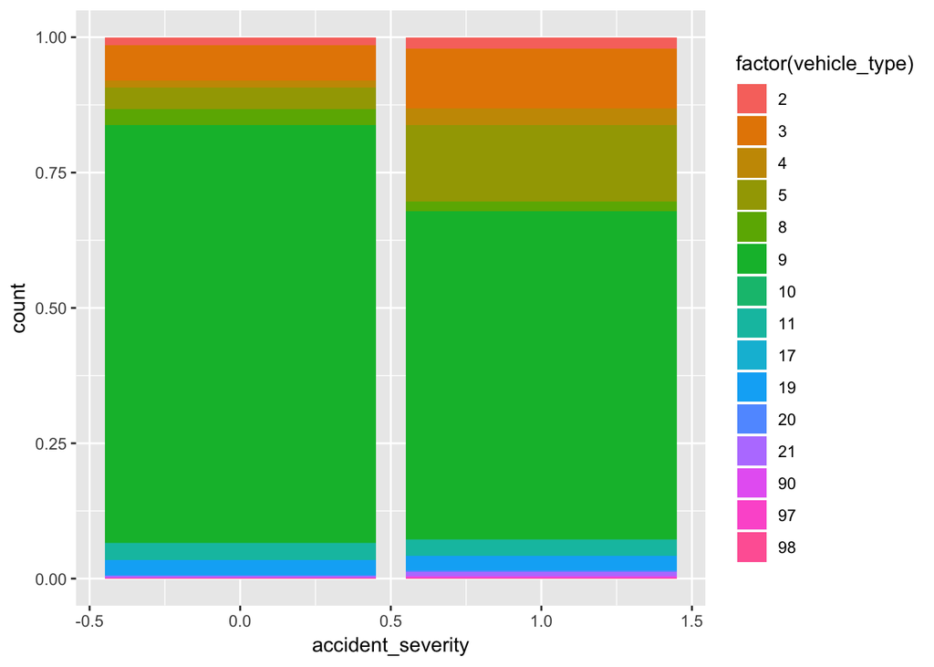

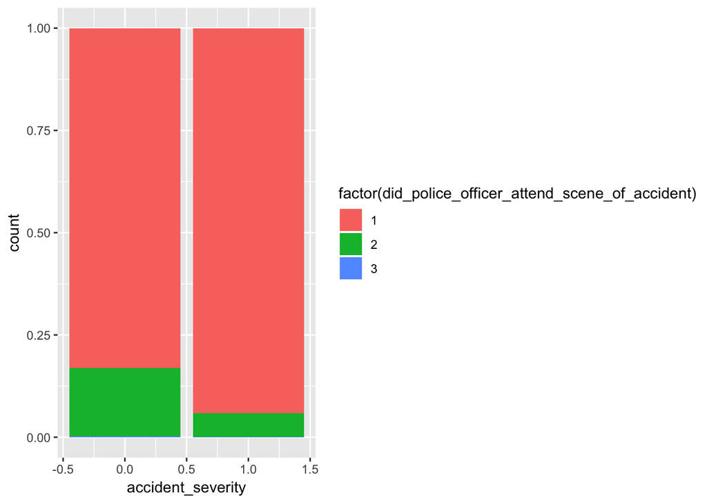

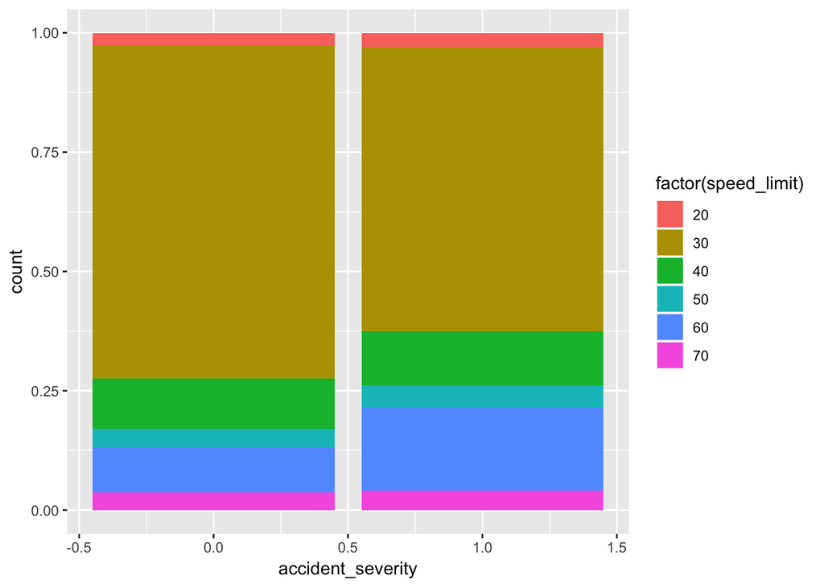

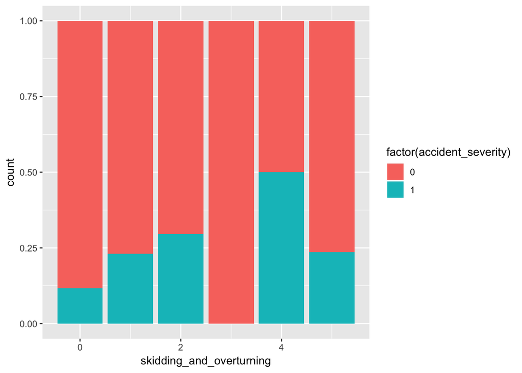

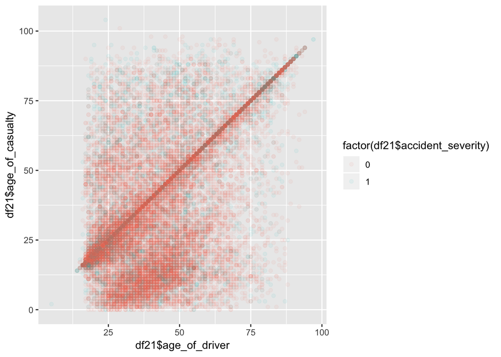

## 1.5 哪裡常出現嚴重車禍

[interactive chart not shown]

- 在大城市，如倫敦、伯明函這樣的都市，由於人口多，車流量多，事故發生的也多，而也有較多的死亡車禍發生。

## 1.6 車齡、天氣、路面狀況等影響

[output not shown]

# 2 Prediction

- 預測在什麼情況下會發生死亡事故

## 2.1 隨機森林

[output not shown]